# Chapter 3: Getting Started with Data in R

# Overview

- What is R?
- Data Carpentry

# The R Programming Language

- Free, open-source
- Powerful, professional, widely-used
- Optimized for statistics, ML
- Huge community of support (CRAN)
- Installation instructions (hopefully you did this already)

# Data Carpentry

## Work in Pairs

- Please pair up (your choice).
  - At least one person in each pair needs to have a device that can use RStudio (installed or using posit.cloud). This person is the *Operator*.
  - Ideally, everyone has an RStudio-enabled device. If you don’t, you can still take notes by keeping track of the code and trying it on your own later.

## Data Carpentry

- Fundamental tools for working with data.
  - Open
  - Reproducible
- Live Coding
  - I type, you type.
  - Challenges

## Group Activity

Follow along with the code. Do the challenges. Record answers to any questions asked.

## Load Packages

```r
library(openintro)
library(tidyverse)
```

## Glimpse, view, and help

```r
glimpse(hsb2)
view(hsb2)
?hsb2
```

## Count (and pipes)

```r
hsb2 %>%
  count(schtyp)
```

```
# A tibble: 2 × 2
  schtyp      n
  <fct>   <int>
1 public    168
2 private    32
```

## Challenge

Challenge: How many different values of the `race` variable are there in the data, and how many observations are in each level?

## Make scatterplots

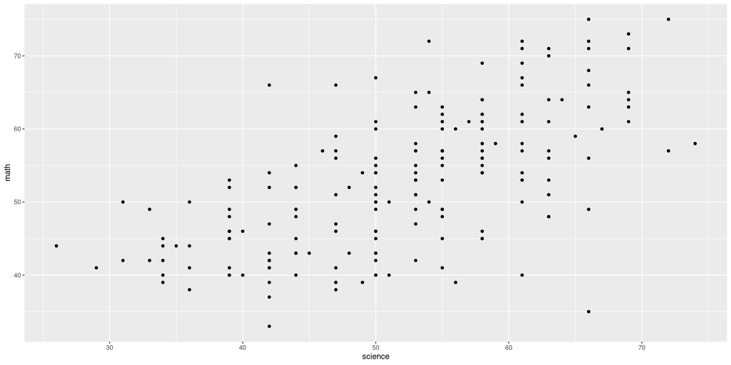

```r
hsb2 %>%
  ggplot(aes(x = science, y = math)) +
  geom_point()
```

## Group by color

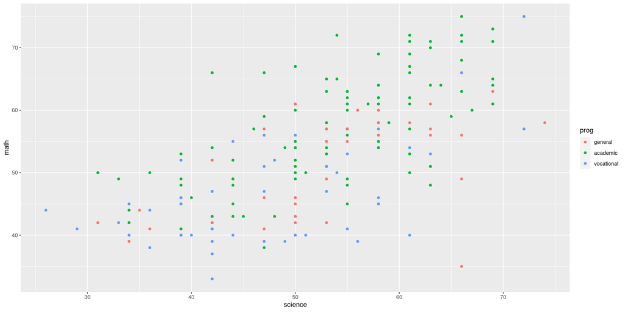

```r
hsb2 %>%
  ggplot(aes(x = science, y = math, color = prog)) +
  geom_point()
```

## Challenge

**Challenge:** Take a look at the email50 data frame. Count the number of emails that are spam and the number that are not spam. Make a scatterplot of two of the quantitative variables in the data set, colored by one of the categorical variables.